# Lasso regularization

Filippo Biscarini

7/8/2020

```r
library("knitr")
library("glmnet")
```

```r
library("ggplot2")
library("tidyverse")
library("tidymodels")
library("data.table")
```

## Lasso-penalised logistic regression using tidymodels

For this illustration, we will use the metabolomics dataset on NMR spectroscopy metabolite abundances in diabetes patients (with controls):

```r
mtbsl1 <- fread("../data/MTBSL1.tsv")
nrow(mtbsl1)
```

```
## [1] 132
```

```r
head(mtbsl1)
```

```
##       Primary ID Gender Metabolic_syndrome [0.10 .. 0.14] [0.14 .. 0.16]
## 1: ADG10003u_007   Male  diabetes mellitus      0.0108030     0.00143490
## 2: ADG10003u_008   Male  diabetes mellitus      0.0031735     0.00000000
## 3: ADG10003u_009   Male  diabetes mellitus      0.0000000     0.00000000
## 4: ADG10003u_010   Male  diabetes mellitus      0.0081798     0.00000000
## 5: ADG10003u_015 Female  diabetes mellitus      0.0183760     0.00083177
## 6: ADG10003u_016 Female  diabetes mellitus      0.0145490     0.00233040
##    [0.16 .. 0.21] [0.21 .. 0.24] [0.24 .. 0.29] [0.29 .. 0.32] [0.32 .. 0.35]
## 1:      0.0091003      0.0000000      0.0000000      0.0000000      0.0000000
## 2:      0.0044487      0.0000000      0.0000000      0.0000000      0.0011089
## 3:      0.0000000      0.0000000      0.0000000      0.0000000      0.0000000
## 4:      0.0012897      0.0000000      0.0000000      0.0000000      0.0000000
## 5:      0.0236020      0.0059512      0.0068872      0.0055841      0.0027941
## 6:      0.0170260      0.0061882      0.0090057      0.0032542      0.0044506
##    [0.35 .. 0.39] [0.39 .. 0.45] [0.45 .. 0.48] [0.48 .. 0.51] [0.51 .. 0.53]
```

[output cut: 258 more lines]

```r
names(mtbsl1)[c(4:ncol(mtbsl1))] <- paste("mtbl",seq(1,ncol(mtbsl1)-3), sep = "_")
table(mtbsl1$Metabolic_syndrome,mtbsl1$Gender)
```

```
##
##                     Female Male
##   Control Group         28   56
##   diabetes mellitus     26   22
```

We see that the metabolites abundances have largely different scales/magnitudes, and it could be a good idea to normalise them before running the model (remember that Lasso constraints the size of the coefficients, and these depends on the magnitude of each variable $\rightarrow$ same $\lambda$ applied to all variables)

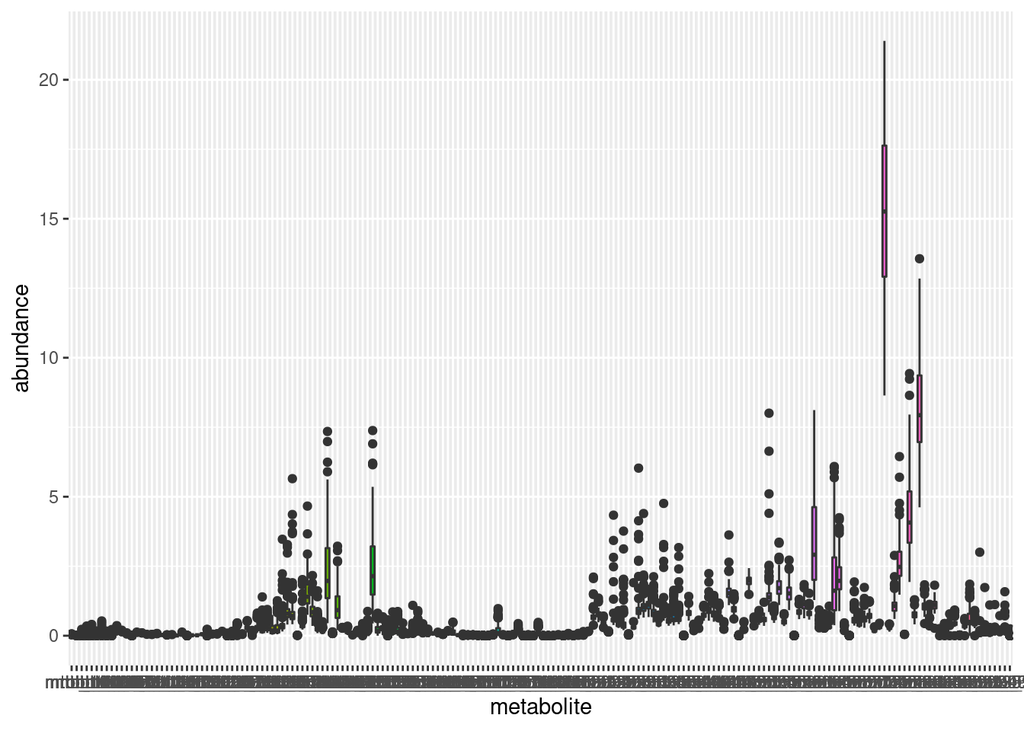

```r
library("repr")
options(repr.plot.width=14, repr.plot.height=8)

mm_diab <- mtbsl1 %>%
  gather(key = "metabolite", value = "abundance", -c(`Primary ID`,Gender,Metabolic_syndrome))

mm_diab %>%
  ggplot(aes(metabolite, abundance, fill = as.factor(metabolite))) +
  geom_boxplot(show.legend = FALSE)
```

### Training and test sets

We now split the data in the training and test sets:

```r
diab_dt <- select(mtbsl1, -c(`Primary ID`, Gender)) ## remove gender for the moment, and keep only mìnumeric features for convinience
mtbsl1_split <- initial_split(diab_dt, strata = Metabolic_syndrome)
mtbsl1_train <- training(mtbsl1_split)
mtbsl1_test <- testing(mtbsl1_split)
```

### Preprocessing

We remove variables with zero variance (no variability, not informative) and normalise all numeric variables:

```r
## build a recipe for preprocessing
mtbsl1_rec <- recipe(Metabolic_syndrome ~ ., data = mtbsl1_train) %>%
  # update_role(`Primary ID`, new_role = "ID") %>%
  step_zv(all_numeric(), -all_outcomes()) %>%
  step_normalize(all_numeric(), -all_outcomes())

print(mtbsl1_rec)
```

```
## Data Recipe
##
## Inputs:
##
##       role #variables
##    outcome          1
##  predictor        188
##
## Operations:
##
## Zero variance filter on all_numeric(), -all_outcomes()
## Centering and scaling for all_numeric(), -all_outcomes()
```

```r
mtbsl1_prep <- mtbsl1_rec %>%
  prep(strings_as_factors = FALSE)

print(mtbsl1_prep)
```

```
## Data Recipe
##
## Inputs:
##
##       role #variables
##    outcome          1
##  predictor        188
##
## Training data contained 99 data points and no missing data.
##
## Operations:
##
## Zero variance filter removed no terms [trained]
## Centering and scaling for mtbl_1, mtbl_2, mtbl_3, mtbl_4, mtbl_5, ... [trained]
```

```r
mtbsl1_train <- juice(mtbsl1_prep)
```

## The Lasso model

We start by specifying our Lasso model:

- it’s logistic regression for a classification problem
- we set the $\lambda$ parameter (penalty) to the arbitrary value of 0.1
- mixture: amount of L1 regularization, when 1 it’s Lasso (0 is Ridge regression)
- the engine is set to `glmnet`

Then we add everything to a workflow object, piecewise, and fit the Lasso model:

```r
lasso_spec <- logistic_reg(mode = "classification", penalty = 0.1, mixture = 1) %>%
  set_engine("glmnet")
```

```r
wf <- workflow() %>%
  add_recipe(mtbsl1_rec)
```

```r
lasso_fit <- wf %>%
  add_model(lasso_spec) %>%
  fit(data = mtbsl1_train)
```

```r
lasso_fit %>%
  pull_workflow_fit() %>%
  tidy()
```

```
## # A tibble: 189 x 3
##    term        estimate penalty
##    <chr>          <dbl>   <dbl>
##  1 (Intercept)  -0.692      0.1
##  2 mtbl_1        0          0.1
##  3 mtbl_2        0          0.1
##  4 mtbl_3        0          0.1
##  5 mtbl_4        0          0.1
##  6 mtbl_5        0          0.1
##  7 mtbl_6        0          0.1
##  8 mtbl_7        0          0.1
##  9 mtbl_8        0.0174     0.1
## 10 mtbl_9        0          0.1
## # … with 179 more rows
```

```r
lasso_fit %>%
  pull_workflow_fit() %>%
  tidy() %>%
  filter(estimate > 0)
```

```
## # A tibble: 8 x 3
##   term     estimate penalty
##   <chr>       <dbl>   <dbl>
## 1 mtbl_8    0.0174      0.1
## 2 mtbl_28   0.276       0.1
## 3 mtbl_38   0.140       0.1
## 4 mtbl_48   0.0424      0.1
## 5 mtbl_101  0.00863     0.1
## 6 mtbl_104  0.0267      0.1
## 7 mtbl_141  0.180       0.1
## 8 mtbl_164  0.536       0.1
```

## Tuning the hyperparameters

We use k-fold cross-validation to tune the hyperparameters ($\lambda$ penalty in this case) in the training set:

```r
diab_cv <- vfold_cv(mtbsl1_train, v=5, repeats = 10, strata = Metabolic_syndrome)

tune_spec <- logistic_reg(penalty = tune(), mixture = 1) %>%
  set_engine("glmnet")

lambda_grid <- grid_regular(penalty(), levels = 50, filter = penalty <= .05)
print(lambda_grid)
```

```
## # A tibble: 43 x 1
##     penalty
##       <dbl>
##  1 1.00e-10
##  2 1.60e-10
##  3 2.56e-10
##  4 4.09e-10
##  5 6.55e-10
##  6 1.05e- 9
##  7 1.68e- 9
##  8 2.68e- 9
##  9 4.29e- 9
## 10 6.87e- 9
## # … with 33 more rows
```

```r
doParallel::registerDoParallel()

lasso_grid <- tune_grid(
  wf %>% add_model(tune_spec),
  resamples = diab_cv,
  grid = lambda_grid
)
lasso_grid %>%
  collect_metrics()
```

```
## # A tibble: 86 x 7
##     penalty .metric  .estimator  mean     n std_err .config
##       <dbl> <chr>    <chr>      <dbl> <int>   <dbl> <chr>
##  1 1.00e-10 accuracy binary     0.930    50 0.00795 Preprocessor1_Model01
##  2 1.00e-10 roc_auc  binary     0.981    50 0.00330 Preprocessor1_Model01
##  3 1.60e-10 accuracy binary     0.930    50 0.00795 Preprocessor1_Model02
##  4 1.60e-10 roc_auc  binary     0.981    50 0.00330 Preprocessor1_Model02
##  5 2.56e-10 accuracy binary     0.930    50 0.00795 Preprocessor1_Model03
##  6 2.56e-10 roc_auc  binary     0.981    50 0.00330 Preprocessor1_Model03
##  7 4.09e-10 accuracy binary     0.930    50 0.00795 Preprocessor1_Model04
##  8 4.09e-10 roc_auc  binary     0.981    50 0.00330 Preprocessor1_Model04
##  9 6.55e-10 accuracy binary     0.930    50 0.00795 Preprocessor1_Model05
## 10 6.55e-10 roc_auc  binary     0.981    50 0.00330 Preprocessor1_Model05
## # … with 76 more rows
```

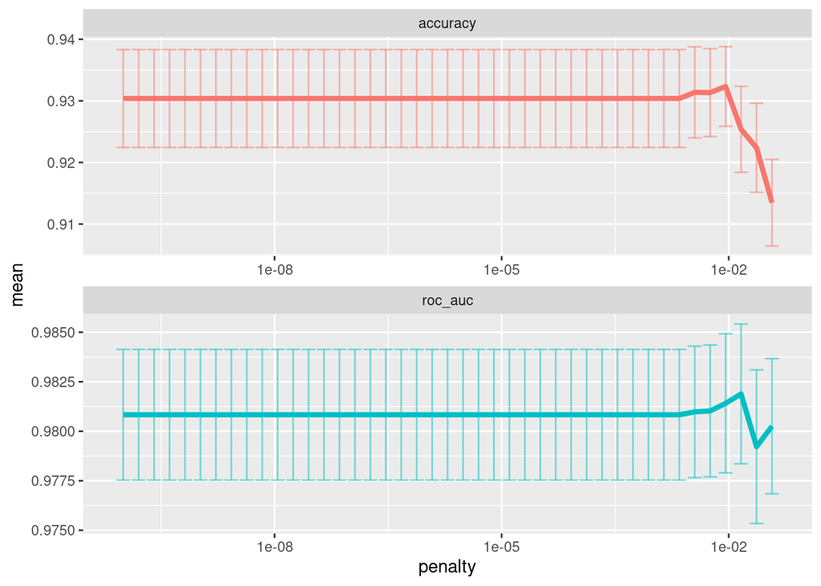

```r
lasso_grid %>%
  collect_metrics() %>%
  ggplot(aes(penalty, mean, color = .metric)) +
  geom_errorbar(aes(
    ymin = mean - std_err,
    ymax = mean + std_err
  ),
  alpha = 0.5
  ) +
  geom_line(size = 1.5) +
  facet_wrap(~.metric, scales = "free", nrow = 2) +
  scale_x_log10() +
  theme(legend.position = "none")
```

```r
lowest_roc <- lasso_grid %>%
  select_best("roc_auc")

print(lowest_roc)
```

```
## # A tibble: 1 x 2
##   penalty .config
##     <dbl> <chr>
## 1  0.0146 Preprocessor1_Model41
```

```r
final_lasso <- finalize_workflow(
  wf %>% add_model(tune_spec),
  lowest_roc
)

print(final_lasso)
```

```
## ══ Workflow ════════════════════════════════════════════════════════════════════
## Preprocessor: Recipe
## Model: logistic_reg()
##
## ── Preprocessor ────────────────────────────────────────────────────────────────
## 2 Recipe Steps
##
## ● step_zv()
## ● step_normalize()
##
## ── Model ───────────────────────────────────────────────────────────────────────
## Logistic Regression Model Specification (classification)
##
## Main Arguments:
##   penalty = 0.0145634847750124
##   mixture = 1
##
## Computational engine: glmnet
```

### Variable importance

```r
library("vip")
```

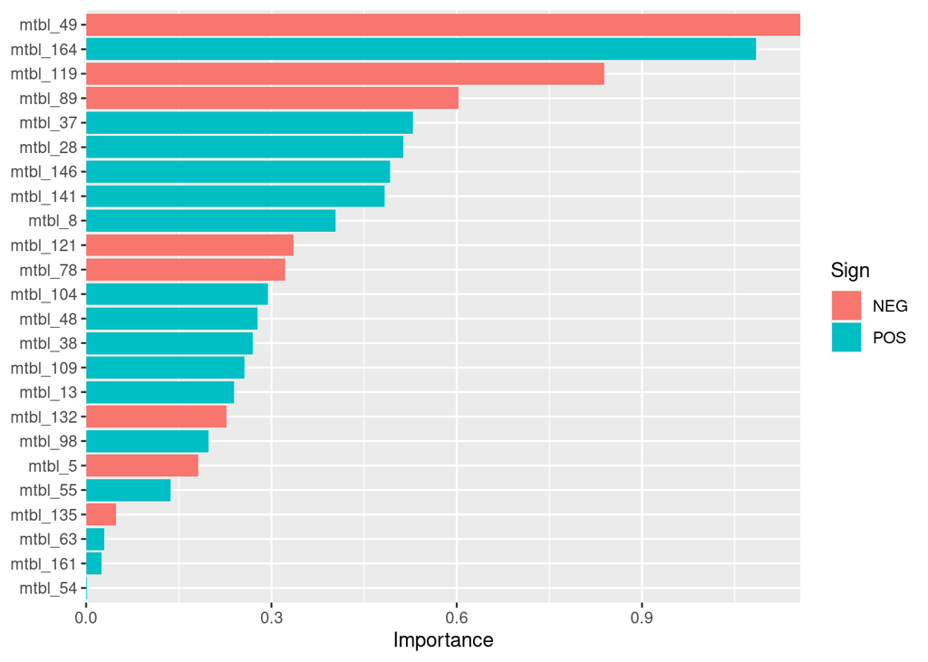

```r
final_lasso %>%
  fit(mtbsl1_train) %>%
  pull_workflow_fit() %>%
  vi(lambda = lowest_roc$penalty) %>%
  mutate(
    Importance = abs(Importance),
    Variable = fct_reorder(Variable, Importance)
  ) %>%
  filter(Importance > 0) %>%
  ggplot(aes(x = Importance, y = Variable, fill = Sign)) +
  geom_col() +
  scale_x_continuous(expand = c(0, 0)) +
  labs(y = NULL)
```

## Testing the model

```r
lr_res <- last_fit(
  final_lasso,
  mtbsl1_split
)

lr_res %>%
  collect_metrics()
```

```
## # A tibble: 2 x 4
##   .metric  .estimator .estimate .config
##   <chr>    <chr>          <dbl> <chr>
## 1 accuracy binary         0.909 Preprocessor1_Model1
## 2 roc_auc  binary         0.964 Preprocessor1_Model1
```

```r
lr_res %>% collect_predictions() %>%
  group_by(.pred_class,Metabolic_syndrome) %>%
  summarise(N=n()) %>%
  spread(key = ".pred_class", value = N)
```

```
## # A tibble: 2 x 3
##   Metabolic_syndrome `Control Group` `diabetes mellitus`
##   <fct>                        <int>               <int>
## 1 Control Group                   21                  NA
## 2 diabetes mellitus                3                   9
```

```r
mtbsl1_testing <- mtbsl1_prep %>% bake(testing(mtbsl1_split)) ## preprocess test data

final_lasso_fit <- fit(final_lasso, data = mtbsl1_train) ## fit final model on the training set

final_lasso_fit %>%
  predict(mtbsl1_testing, type = "class") %>%
  bind_cols(mtbsl1_testing) %>%
  # metrics(truth = Metabolic_syndrome, estimate = .pred_class)
  group_by(.pred_class,Metabolic_syndrome) %>%
  summarise(N=n()) %>%
  spread(key = ".pred_class", value = N)
```

```
## # A tibble: 2 x 3
##   Metabolic_syndrome `Control Group` `diabetes mellitus`
##   <chr>                        <int>               <int>
## 1 Control Group                   21                  NA
## 2 diabetes mellitus                3                   9
```

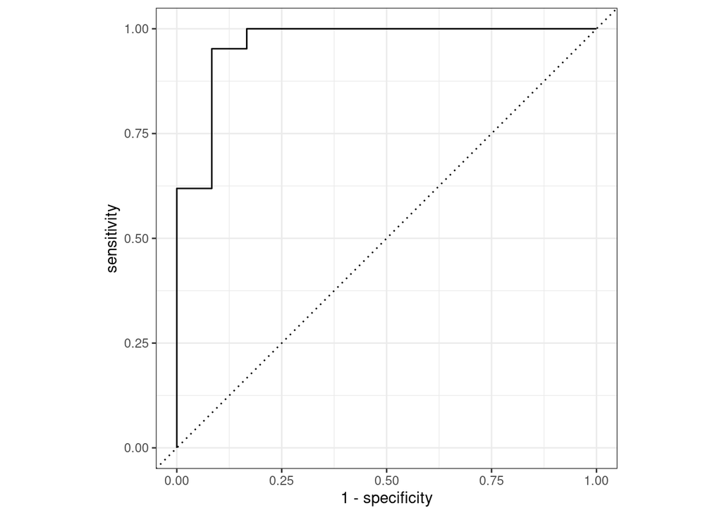

```r
lr_auc <-
  lr_res %>%
  collect_predictions() %>%
  roc_curve(Metabolic_syndrome,`.pred_Control Group`) %>%
  mutate(model = "Logistic Regression")

autoplot(lr_auc)
```

## Add gender (factor) to the Lasso model

To add factors to the Lasso model (engine `glmnet`) we need to use [one hot encoding](https://hackernoon.com/what-is-one-hot-encoding-why-and-when-do-you-have-to-use-it-e3c6186d008f)

```r
diab_dt <- model.matrix(~ ., mtbsl1[,"Gender"]) %>% as_tibble() %>% select(GenderMale) %>% rename(gender = GenderMale) %>%
bind_cols(diab_dt)

head(diab_dt)
```

```
## # A tibble: 6 x 190
##   gender Metabolic_syndr…  mtbl_1  mtbl_2  mtbl_3  mtbl_4  mtbl_5  mtbl_6
##    <dbl> <chr>              <dbl>   <dbl>   <dbl>   <dbl>   <dbl>   <dbl>
## 1      1 diabetes mellit… 0.0108  1.43e-3 0.00910 0       0       0
## 2      1 diabetes mellit… 0.00317 0.      0.00445 0       0       0
## 3      1 diabetes mellit… 0       0.      0       0       0       0
## 4      1 diabetes mellit… 0.00818 0.      0.00129 0       0       0
## 5      0 diabetes mellit… 0.0184  8.32e-4 0.0236  0.00595 0.00689 0.00558
## 6      0 diabetes mellit… 0.0145  2.33e-3 0.0170  0.00619 0.00901 0.00325
## # … with 182 more variables: mtbl_7 <dbl>, mtbl_8 <dbl>, mtbl_9 <dbl>,
## #   mtbl_10 <dbl>, mtbl_11 <dbl>, mtbl_12 <dbl>, mtbl_13 <dbl>, mtbl_14 <dbl>,
## #   mtbl_15 <dbl>, mtbl_16 <dbl>, mtbl_17 <dbl>, mtbl_18 <dbl>, mtbl_19 <dbl>,
## #   mtbl_20 <dbl>, mtbl_21 <dbl>, mtbl_22 <dbl>, mtbl_23 <dbl>, mtbl_24 <dbl>,
## #   mtbl_25 <dbl>, mtbl_26 <dbl>, mtbl_27 <dbl>, mtbl_28 <dbl>, mtbl_29 <dbl>,
## #   mtbl_30 <dbl>, mtbl_31 <dbl>, mtbl_32 <dbl>, mtbl_33 <dbl>, mtbl_34 <dbl>,
## #   mtbl_35 <dbl>, mtbl_36 <dbl>, mtbl_37 <dbl>, mtbl_38 <dbl>, mtbl_39 <dbl>,
## #   mtbl_40 <dbl>, mtbl_41 <dbl>, mtbl_42 <dbl>, mtbl_43 <dbl>, mtbl_44 <dbl>,
## #   mtbl_45 <dbl>, mtbl_46 <dbl>, mtbl_47 <dbl>, mtbl_48 <dbl>, mtbl_49 <dbl>,
## #   mtbl_50 <dbl>, mtbl_51 <dbl>, mtbl_52 <dbl>, mtbl_53 <dbl>, mtbl_54 <dbl>,
## #   mtbl_55 <dbl>, mtbl_56 <dbl>, mtbl_57 <dbl>, mtbl_58 <dbl>, mtbl_59 <dbl>,
## #   mtbl_60 <dbl>, mtbl_61 <dbl>, mtbl_62 <dbl>, mtbl_63 <dbl>, mtbl_64 <dbl>,
## #   mtbl_65 <dbl>, mtbl_66 <dbl>, mtbl_67 <dbl>, mtbl_68 <dbl>, mtbl_69 <dbl>,
## #   mtbl_70 <dbl>, mtbl_71 <dbl>, mtbl_72 <dbl>, mtbl_73 <dbl>, mtbl_74 <dbl>,
## #   mtbl_75 <dbl>, mtbl_76 <dbl>, mtbl_77 <dbl>, mtbl_78 <dbl>, mtbl_79 <dbl>,
## #   mtbl_80 <dbl>, mtbl_81 <dbl>, mtbl_82 <dbl>, mtbl_83 <dbl>, mtbl_84 <dbl>,
## #   mtbl_85 <dbl>, mtbl_86 <dbl>, mtbl_87 <dbl>, mtbl_88 <dbl>, mtbl_89 <dbl>,
## #   mtbl_90 <dbl>, mtbl_91 <dbl>, mtbl_92 <dbl>, mtbl_93 <dbl>, mtbl_94 <dbl>,
## #   mtbl_95 <dbl>, mtbl_96 <dbl>, mtbl_97 <dbl>, mtbl_98 <dbl>, mtbl_99 <dbl>,
## #   mtbl_100 <dbl>, mtbl_101 <dbl>, mtbl_102 <dbl>, mtbl_103 <dbl>,
## #   mtbl_104 <dbl>, mtbl_105 <dbl>, mtbl_106 <dbl>, …
```

#### Interactive ecercise

We’ll now rerun a Lasso-penalised logistic regression model including Gender as feature, going together through the steps involved in Lasso models with `tidymodels`:

1. splitting the data
2. preprocessing
3. hyperparameters tuning
4. fitting the final model
5. predictions on the test set

```r
## code here
```

```r
## code here
```